[HOME](https://iwuvuu.github.io)

# Algoritmizace

Algoritmus je přesný postup, který je potřeba k vykonání určité činnosti. Není závislý na programovacím jazyce ani na čáse.

# Podmínky algoritmů

Začátek a konec - Algoritmus, který není ukončený (stále probíhá není žádoucí) - jediná možnost jak tento algoritmus ukončit je vypnout počítač, nebo ukončit proces. Takový stav nazýváme v informatice nekonečný cyklus/zacyklení. Nejčastěji je zapříčeněn špatně napsanou podmínkou, která nikdy nebude splněna.

Věcná spřavnost - Algoritmus nepočítá správně - tak jak by měl. Nejčastěji je tato chyba vzniklá při přepisu např. matematického vzorce - například chybějící závorka, špatně zapsaný zlomek, odmocnina apod…. Takto zapsaný program funguje, ale nepočítá správně (proto bychom si daný program měli vždy vyzkouset na nějakém příkladě…)

Jednoznačnost - Pokud se má program rozhodnout - vždy to musí být na základě nějaké podmínky. Pokud chceme aby se program rozold náhodně například při hodu kostkou musí být vždy uvedeno.

Obecnost - Každý algoritmus musí být co nejobecnější, aby bylo možné pomocí něj řešit co nejširší množství úloh. Algoritmus pro součet dvou čísel například 58 a 59 sice můžeme zsapsat jako 58+59, ale takový algoritmus není obecný - umí řešti pouze jednu úlohu. Mnohem lepší je algoritmus, který sčítá dvě proměnné například A+B, pomocí takového algoritmu můžeme řešit nejenom předešlou úlohu, ale mnoho dalších.

Opakovatelnost - při zadánístejných vstupních dat dospěje vždy ke stejným výsledkům.

Srozumitelnou - Každý algoritmus musí být natolik srozumitelný, aby mu rozumel nejen programátor, který podle něj bude vytvářet program, ale i sám tvůrce, jenž bude po nějakém čase nucen algoritmus na přání uživatele upravit nebo rozšířit.

Pro větší srozumitelnost je důležité využívat komentáře v dostatečné míře.

# Zápis algoritmu

## Slovní vyjádření

Používá se u lidí, kteří nemají programátorské vzdělání, a nelze předpokládat, že by akceptovala jiné než slovní vyjádření. Používá se u receptů.

- výhody
  - domluvíte se i s laikem, je to jediná možnost, když nic nezbývá
- nevýhody:
  - ze všech forem zápisu algoritmů je nejméně přehledná
  - slovně je velmi složité zapsat algoritmus, který by nevyžadoval lidského domýšlení a zkušeností. Příklad jak slovní vyjádření nedokáže jednoduše přenést význam: [Odkaz na youtube](https://www.youtube.com/watch?v=cDA3_5982h8)

## Rozhodovací tabulky

Jsou velice vhodné v případech, kdy se vyskytuje několik možností a vlastní řešení je pro káždkou jednoduše popsatelné.

Příklad: Rozvrh hodin pro určitou konkrétní třídu

Nehodí se pro každý typ úloh, pokud by u některé možnosti algoritmus vyžadoval delší vysvětlování, pak by tabulka ztratila přehlednost a prevzala by nevýhody slovního zápisu.

## Další formy zápisu

Existuje také matematický zápis pomocí matematických rovnic a operací a samozřejmě počítačový program.

## Vývojové diagramy

Vývojový diagram je symbolický algoritmický jazyk, který se používá pro názorné zobrazení algoritmu, a jedna z nejdokonalejších forem zápisu algoritmů. Používá se zejména při vývoji softwaru - jako komunikační prostředek při týmové spolupráci analytiků s programátory; k dokumentačním účelům - vývojový diagram je přehlednější než výpis programu + nepodléhá času jako například zápis v programovacím jazyce.

### Symboly vývojových diagramů

#### Mezní značka:

Určuje začátek a konec diagramu a místo, kde se má algoritmus přerušit.

#### Vstup nebo výstup

Načtení dat A, B z externího zdroje (např. z klávesnice) resp. Předepisuje výstup dat a jejich zobrazení (např. na obrazovce)

#### Zpracování

Činnost programu, během níž dochází k vytváření nových dat.

# Podmínky v algoritmech

Pomocí podmínek můžeme řídit algoritmus: a to ve dvou směrech. Pokud je podmínka splněan bude pokračovat běh programu v prním směru, pokud ne, tak ve druhém.

- Využití podmínek:
  - Ošetřování nežádoucích důsledků v algoritmech
  - Rozvětvení algoritmu z důvodu více konkrétních řešení

## Nežádoucí důsledky

Dělení nulou - Dělit nulou se nesmí. Počítač to neví a my mu to musíme říct. V případě, že bychom tuto podmínku neu§vedli, program by nám havaroval.

Odmocnina - Záporná odmocnina nemá řešení v oboru $\mathbb{R}$

## Značení rozhodovacího bloku:

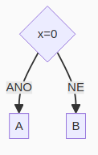

Je jedno na jaké straně bude pravdivá nebo nepravdivá odpověď. Záleží, která bude později delší a kde je více místa.

## Ukázkové příklady:

### Jednoduché rozhodování

Následující algoritmus určuje jestli je zadané číslo kladné, záporné. Je důležité si pamatovat, že nula není ani kladné ani záporné číslo.

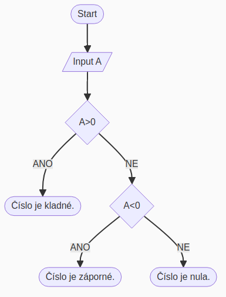

### Omezený cyklus

Na tomto konkrétním příkladu je uživatel někde v baru a počítá kolik panáků si dal. Začíná na 0 panácích a pokaždé se ptá, jestli už neměl moc. Pokud ano algoritmus se ukončí pokud ne, tak se cyklus opakuje znovu. Písmeno $n$ značí počet vypitých panáků.

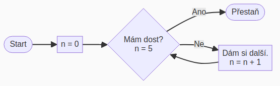

Vidíme, že dokud $n$ nebude rovno 5 bude cyklus vždy negativní a odpověď bude ne, což vede na větev “Dám si další.”. Zde se k $n$ přičítá hodnota samotného $n$ a k tomu jednička (hodnota $n$ se zvedne o 1). Tento cyklus se opakuje dokud $n$ nebude rovno 5.

### Sheldonův lagoritmus přátelství

Konkrétně část o společných zájmech, kde si můžeme ukázat špatně napsaný algoritmus.

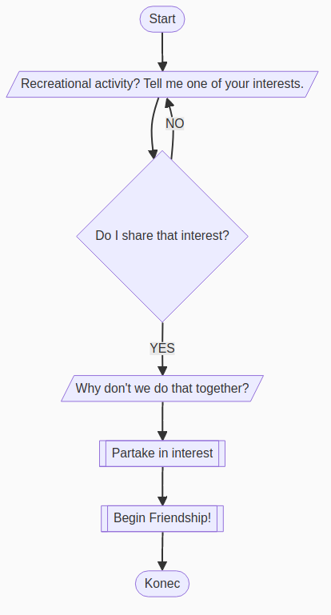

Zde ale narážíme na problém neukončeného cyklu. Protože pokud Sheldon nenajde žádný společný koníček, tak nikdy neopustí cyklus.

V seriálu vyřešili tento problém takto:

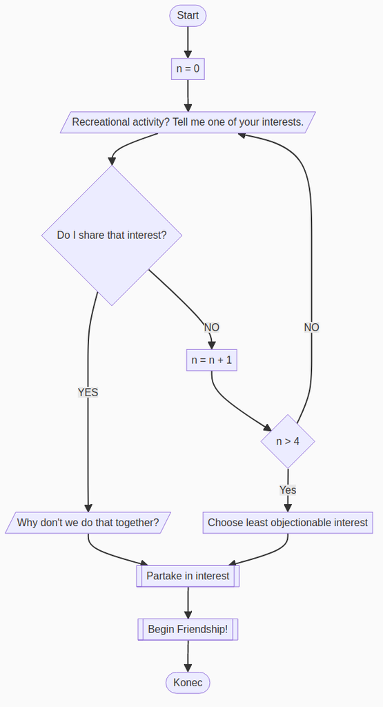

Pro **výuku algoritmů** se využívá umělých jazyků. Populární je blokový programovací jazyk pro děti Scratch. Ten je postaven na propojování barevných bloků s různou funkcí, které potom společně umožní programu fungovat. Na podobném principu funguje třeba Blockly od Google.

Zajímavá metoda pro pochopení logiky algoritmů je **vizaulizace algoritmů**. Znamená to, že jednotlivé kroky se ukazují pomocí grafických věmů (a né pouze jako kód), díky tomu lze lépe pochopit fungování programů a datových struktur. Vizualizace může v reálném čásu ukazovat jak se algorutmus pracuje a jak se v něm data pohybují a co dělají (kam se řadí, kde prochází…). Například u algoritmu řazení čísel se mohou čisla zapsat v řádku a budou navzájem měnit svoji pozici. Hezkým příkladem je [visualgo.net](https://visualgo.net/en)

Mimo programování se algoritmy využívájí i v jiných vědních oborech, např. k **lékařské diagnostice**. Pomocí algoritmů jsou lékaři lépe schopni analyzovat zdravotní data a odhalit nemoci a problémy. Příkladně v radiologii můžeme pomocí algoritmů analyzovat rentgenové snímky a detekovat nemoci nebo zlomeniny.

# Praktická část - Programování v Pythonu – práce s textovým řetězcem a Základní matematické operace

[Odkaz na vide](https://youtu.be/QKVGt_QBxC4)